# ForageModv02 Supplementary Analysis

## Population maintenance?

First, we checked to see whether all model runs maintained a population across all 2000 ticks.

```r
all.exp = unique(data$exp)

end.tick = unique(data$`tick-limit`)
fd = data %>% filter(ticks == end.tick)
finished.exp = unique(fd$exp)

finished.data = data %>% filter(exp %in% finished.exp)
unfinished.data = data %>% filter(!(exp %in% finished.exp))
length(unique(unfinished.data$exp))
```

```
## [1] 1
```

Only one of our runs resulted in population extinction. Below you can see the model parameters that result in this:

```r
unfinished.data %>% select_at(c(parameters)) %>% first() %>% kable()
```

| natural-ignition | cycle-duration | veg-cycle-start | veg-distribution | burnt-neighbor-limit | burn-cost | burn-veg-type-threshold | movement-model |
| --- | --- | --- | --- | --- | --- | --- | --- |
| 0 | 250 | “productive” | “random” | 4 | 50 | 7 | “Random Walk” |

Because there was only one model run that resulted in population extinction, we do not remove this from the subsequent analyses.

## Correlations of outputs over time

Next, we looked at the correlation between outputs across model runs.

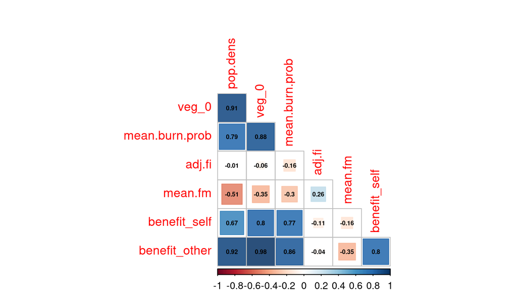

We can see that population density is highly correlated with most of the other outputs. Specifically, there is a high and significant positive correlation between population density and mean burning probability (*mean.burn.prob*). This indicates that large populations are more likely to burn the landscape. This contextualize the positive correlation between population density and proportion of burnt landscape (*veg_0*). We also see that population density is negatively correlated with forager movement (*mean.fm*), meaning foragers move less within large populations. Foragers also move less when they are burning the landscape more frequently.

We also investigated how these correlations change over time by looking at the correlations between outputs at 250 ticks, 1000 ticks, and 2000 ticks. For this, we also include spatial autocorrelation values of vegetation types and burning events, as well as a diversity metric of vegetation types.

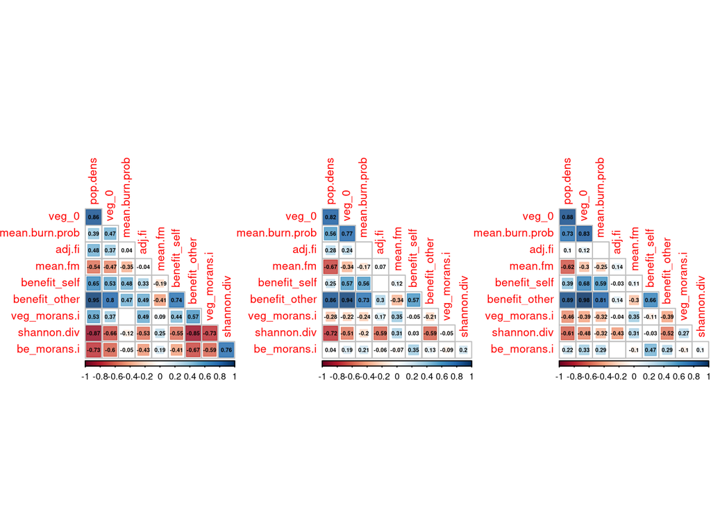

## Population during model run

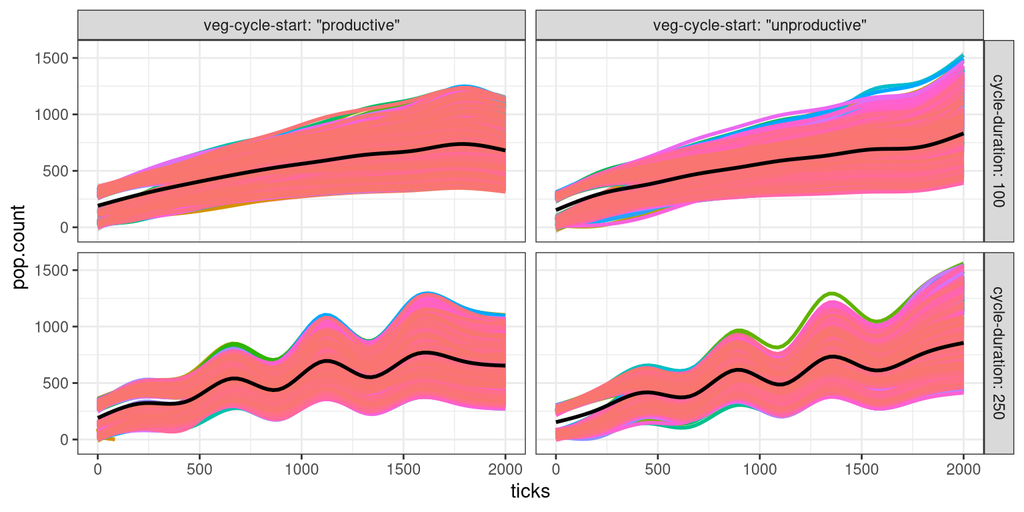

We model population count across model run with a Poisson regression. We model the change in population across time by including “ticks” as a independent variable. We also investigate the interaction between time and model parameters.

```r
#hist(data$pop.count)
#hist(data$pop.dens)

pop.fit1 = glm(pop.dens ~ ticks, data = data, family = "poisson")
pop.fit2 = glm(pop.dens ~ ticks + (`veg-distribution` + `burnt-neighbor-limit` + `burn-cost` + `burn-veg-type-threshold` + `natural-ignition` + `veg-cycle-start` + `movement-model` + `cycle-duration`), data = data, family = "poisson")
pop.fit3 = glm(pop.dens ~ ticks*(`veg-distribution` + `burnt-neighbor-limit` + `burn-cost` + `burn-veg-type-threshold` + `natural-ignition` + `veg-cycle-start` + `movement-model` + `cycle-duration`), data = data, family = "poisson")
anova(pop.fit1, pop.fit2, pop.fit3, test = "Chisq")
```

```
## Analysis of Deviance Table
##
## Model 1: pop.dens ~ ticks
## Model 2: pop.dens ~ ticks + (`veg-distribution` + `burnt-neighbor-limit` +
##     `burn-cost` + `burn-veg-type-threshold` + `natural-ignition` +
##     `veg-cycle-start` + `movement-model` + `cycle-duration`)
## Model 3: pop.dens ~ ticks * (`veg-distribution` + `burnt-neighbor-limit` +
##     `burn-cost` + `burn-veg-type-threshold` + `natural-ignition` +
##     `veg-cycle-start` + `movement-model` + `cycle-duration`)
##   Resid. Df Resid. Dev Df Deviance  Pr(>Chi)
## 1  11523842     267412
## 2  11523833     129619  9   137793 < 2.2e-16 ***
## 3  11523824      94161  9    35458 < 2.2e-16 ***
## ---
## Signif. codes:  0 '***' 0.001 '**' 0.01 '*' 0.05 '.' 0.1 ' ' 1
```

```r
pop.fit3 %>% broom::tidy() %>%
  mutate(p.value = scales::pvalue(p.value)) %>%
  kable()
```

| term | estimate | std.error | statistic | p.value |
| --- | --- | --- | --- | --- |
| (Intercept) | -1.8995313 | 0.0047856 | -396.9279528 | <0.001 |
| ticks | 0.0001711 | 0.0000037 | 45.6480609 | <0.001 |
| `veg-distribution`“random” | -0.0106295 | 0.0030105 | -3.5307882 | <0.001 |
| `burnt-neighbor-limit`4 | 0.1049913 | 0.0037841 | 27.7456838 | <0.001 |
| `burnt-neighbor-limit`8 | 0.0651528 | 0.0037731 | 17.2678365 | <0.001 |
| `burn-cost`50 | -0.0938238 | 0.0030138 | -31.1309558 | <0.001 |
| `burn-veg-type-threshold`7 | 0.0735556 | 0.0030158 | 24.3903835 | <0.001 |
| `natural-ignition`0.05 | 0.0782121 | 0.0030111 | 25.9749165 | <0.001 |
| `veg-cycle-start`“unproductive” | -0.0712632 | 0.0030111 | -23.6668331 | <0.001 |
| `movement-model`“Random Walk” | -0.7150047 | 0.0031134 | -229.6549569 | <0.001 |
| `cycle-duration`250 | 0.0002083 | 0.0030105 | 0.0691999 | 0.945 |
| ticks:`veg-distribution`“random” | 0.0000047 | 0.0000023 | 2.0492173 | 0.040 |
| ticks:`burnt-neighbor-limit`4 | 0.0001964 | 0.0000030 | 66.2603383 | <0.001 |
| ticks:`burnt-neighbor-limit`8 | 0.0002877 | 0.0000029 | 98.0580386 | <0.001 |
| ticks:`burn-cost`50 | -0.0000006 | 0.0000023 | -0.2499680 | 0.803 |
| ticks:`burn-veg-type-threshold`7 | 0.0000763 | 0.0000023 | 32.9183684 | <0.001 |
| ticks:`natural-ignition`0.05 | -0.0000822 | 0.0000023 | -35.5401293 | <0.001 |
| ticks:`veg-cycle-start`“unproductive” | 0.0000605 | 0.0000023 | 26.1715564 | <0.001 |
| ticks:`movement-model`“Random Walk” | 0.0003544 | 0.0000024 | 149.9366366 | <0.001 |
| ticks:`cycle-duration`250 | -0.0000011 | 0.0000023 | -0.4655097 | 0.642 |

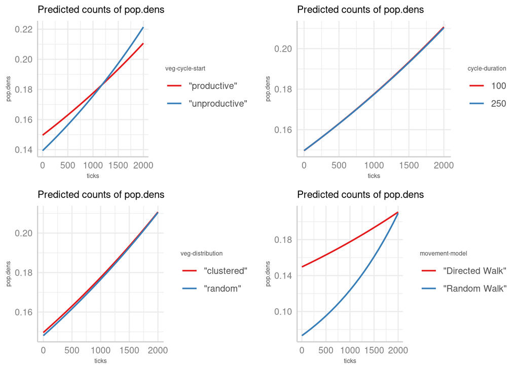

```r
#plot_summs(pop.fit3, scale = T)

ggarrange(
  ggeffects::ggpredict(pop.fit3, terms = c("ticks", "veg-cycle-start")) %>%
    plot(show_data = FALSE, show_ci = FALSE) +
    theme(legend.title = element_text(size = 6), title = element_text(size = 8), axis.title = element_text(size = 6)),
  ggeffects::ggpredict(pop.fit3, terms = c("ticks", "cycle-duration")) %>%
    plot(show_data = FALSE, show_ci = FALSE) +
    theme(legend.title = element_text(size = 6), title = element_text(size = 8), axis.title = element_text(size = 6)),
  ggeffects::ggpredict(pop.fit3, terms = c("ticks", "veg-distribution")) %>%
    plot(show_data = FALSE, show_ci = FALSE) +
    theme(legend.title = element_text(size = 6), title = element_text(size = 8), axis.title = element_text(size = 6)),
  ggeffects::ggpredict(pop.fit3, terms = c("ticks", "movement-model")) %>%
    plot(show_data = FALSE, show_ci = FALSE) +
    theme(legend.title = element_text(size = 6), title = element_text(size = 8), axis.title = element_text(size = 6))
)
```

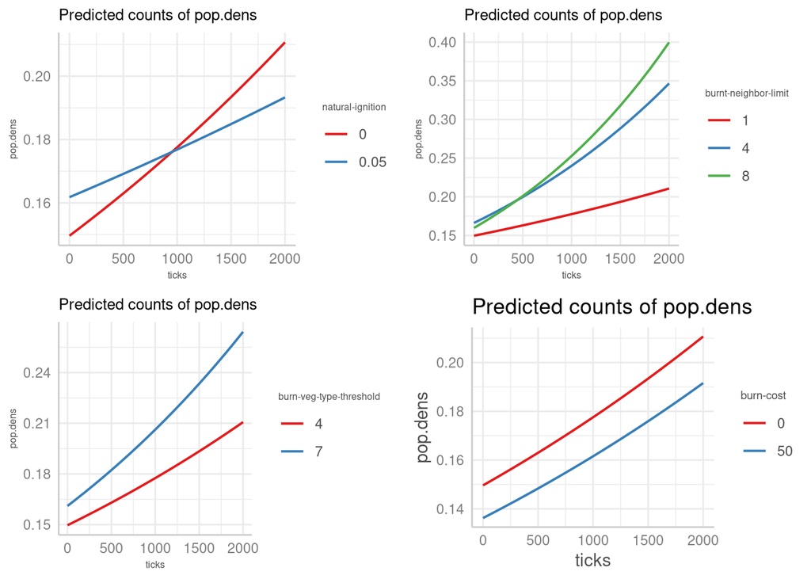

```r
ggarrange(
  ggeffects::ggpredict(pop.fit3, terms = c("ticks", "natural-ignition")) %>%
    plot(show_data = FALSE, show_ci = FALSE) +
    theme(legend.title = element_text(size = 6), title = element_text(size = 8), axis.title = element_text(size = 6)),
  ggeffects::ggpredict(pop.fit3, terms = c("ticks", "burnt-neighbor-limit")) %>%
    plot(show_data = FALSE, show_ci = FALSE) +
    theme(legend.title = element_text(size = 6), title = element_text(size = 8), axis.title = element_text(size = 6)),
  ggeffects::ggpredict(pop.fit3, terms = c("ticks", "burn-veg-type-threshold")) %>%
    plot(show_data = FALSE, show_ci = FALSE) +
    theme(legend.title = element_text(size = 6), title = element_text(size = 8), axis.title = element_text(size = 6)),
  ggeffects::ggpredict(pop.fit3, terms = c("ticks", "burn-cost")) %>%
    plot(show_data = FALSE, show_ci = FALSE) +
    theme(legend.title = element_text(size = 7))
)
```

Population increases over time. The results from the regression analysis demonstrate that population is significantly affected by access to energy. This means that parameters that allow for more energy in the environment, such as relaxed limits to burning (higher *burnt-neighbor-limit*, higher *burn-veg-type-threshold*), or for foragers to access more energy, such as a directed walk (*movement-model*), result in increased population.

## Forager probability of burning patches

We examined the effects of all model parameters on burning probability across model run using linear regressions. We model the effect of the different parameter settings on model behavior. We also model change over model run by including “ticks” as a independent variable. Finally, we investigate the interaction between time and model parameters.

```r
#hist(data$mean.burn.prob)

mbp.fit1 = lm(mean.burn.prob ~ ticks + (.), data = data %>% dplyr::select_at(c("mean.burn.prob", "ticks", parameters)))
mbp.fit2 = lm(mean.burn.prob ~ ticks:(.), data = data %>% dplyr::select_at(c("mean.burn.prob", "ticks", parameters)))
mbp.fit3 = lm(mean.burn.prob ~ ticks*(.), data = data %>% dplyr::select_at(c("mean.burn.prob", "ticks", parameters)))

anova(mbp.fit1, mbp.fit2, mbp.fit3)
```

```
## Analysis of Variance Table
##
## Model 1: mean.burn.prob ~ ticks + (ticks + `natural-ignition` + `cycle-duration` +
##     `veg-cycle-start` + `veg-distribution` + `burnt-neighbor-limit` +
##     `burn-cost` + `burn-veg-type-threshold` + `movement-model`)
## Model 2: mean.burn.prob ~ ticks:(ticks + `natural-ignition` + `cycle-duration` +
##     `veg-cycle-start` + `veg-distribution` + `burnt-neighbor-limit` +
##     `burn-cost` + `burn-veg-type-threshold` + `movement-model`)
## Model 3: mean.burn.prob ~ ticks * (ticks + `natural-ignition` + `cycle-duration` +
##     `veg-cycle-start` + `veg-distribution` + `burnt-neighbor-limit` +
##     `burn-cost` + `burn-veg-type-threshold` + `movement-model`)
##     Res.Df   RSS Df Sum of Sq     F    Pr(>F)
## 1 11523833 26087
## 2 11523833 18204  0    7883.3
## 3 11523824 17896  9     307.9 22030 < 2.2e-16 ***
## ---
## Signif. codes:  0 '***' 0.001 '**' 0.01 '*' 0.05 '.' 0.1 ' ' 1
```

```r
mbp.fit3 %>% broom::tidy() %>%
  mutate(p.value = scales::pvalue(p.value)) %>%
  kable()
```

| term | estimate | std.error | statistic | p.value |
| --- | --- | --- | --- | --- |
| (Intercept) | 0.0802298 | 7.34e-05 | 1093.1911361 | <0.001 |
| ticks | 0.0002993 | 1.00e-07 | 4709.7020189 | <0.001 |
| `natural-ignition`0.05 | 0.0000273 | 4.64e-05 | 0.5892284 | 0.556 |
| `cycle-duration`250 | 0.0002956 | 4.64e-05 | 6.3680282 | <0.001 |
| `veg-cycle-start`“unproductive” | -0.0071228 | 4.64e-05 | -153.4530883 | <0.001 |
| `veg-distribution`“random” | -0.0017156 | 4.64e-05 | -36.9599568 | <0.001 |
| `burnt-neighbor-limit`4 | -0.0128319 | 5.69e-05 | -225.7136130 | <0.001 |
| `burnt-neighbor-limit`8 | -0.0203958 | 5.68e-05 | -358.8017431 | <0.001 |
| `burn-cost`50 | -0.0051959 | 4.64e-05 | -111.9408819 | <0.001 |
| `burn-veg-type-threshold`7 | -0.0009352 | 4.64e-05 | -20.1486786 | <0.001 |
| `movement-model`“Random Walk” | -0.0078737 | 4.64e-05 | -169.6322024 | <0.001 |
| ticks:`natural-ignition`0.05 | -0.0000027 | 0.00e+00 | -68.0910725 | <0.001 |
| ticks:`cycle-duration`250 | -0.0000009 | 0.00e+00 | -21.9829906 | <0.001 |
| ticks:`veg-cycle-start`“unproductive” | -0.0000008 | 0.00e+00 | -20.9226532 | <0.001 |
| ticks:`veg-distribution`“random” | -0.0000017 | 0.00e+00 | -43.0938653 | <0.001 |
| ticks:`burnt-neighbor-limit`4 | 0.0000765 | 0.00e+00 | 1554.3547707 | <0.001 |
| ticks:`burnt-neighbor-limit`8 | 0.0000938 | 0.00e+00 | 1905.1647147 | <0.001 |
| ticks:`burn-cost`50 | -0.0000349 | 0.00e+00 | -867.4557764 | <0.001 |
| ticks:`burn-veg-type-threshold`7 | 0.0000231 | 0.00e+00 | 574.0807838 | <0.001 |
| ticks:`movement-model`“Random Walk” | 0.0000108 | 0.00e+00 | 268.9456912 | <0.001 |

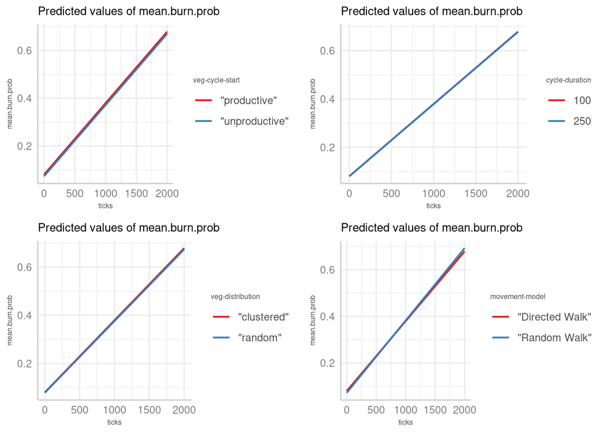

```r
ggarrange(
  ggeffects::ggpredict(mbp.fit3, terms = c("ticks", "veg-cycle-start")) %>%
    plot(show_data = FALSE, show_ci = FALSE) +
    theme(legend.title = element_text(size = 6), title = element_text(size = 8), axis.title = element_text(size = 6)),
  ggeffects::ggpredict(mbp.fit3, terms = c("ticks", "cycle-duration")) %>%
    plot(show_data = FALSE, show_ci = FALSE) +
    theme(legend.title = element_text(size = 6), title = element_text(size = 8), axis.title = element_text(size = 6)),
  ggeffects::ggpredict(mbp.fit3, terms = c("ticks", "veg-distribution")) %>%
    plot(show_data = FALSE, show_ci = FALSE) +
    theme(legend.title = element_text(size = 6), title = element_text(size = 8), axis.title = element_text(size = 6)),
  ggeffects::ggpredict(mbp.fit3, terms = c("ticks", "movement-model")) %>%
    plot(show_data = FALSE, show_ci = FALSE) +
    theme(legend.title = element_text(size = 6), title = element_text(size = 8), axis.title = element_text(size = 6))
)
```

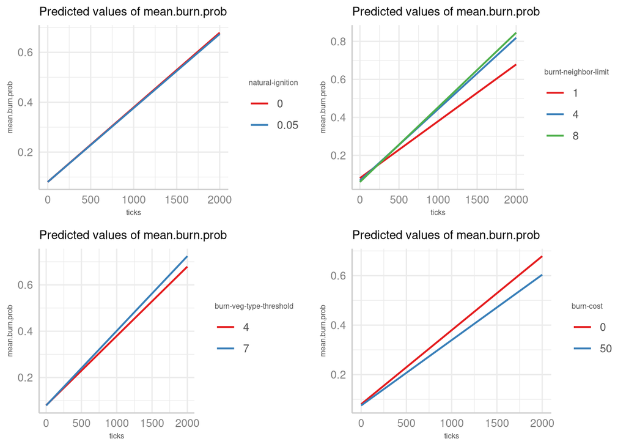

```r
ggarrange(
  ggeffects::ggpredict(mbp.fit3, terms = c("ticks", "natural-ignition")) %>%
    plot(show_data = FALSE, show_ci = FALSE) +
    theme(legend.title = element_text(size = 6), title = element_text(size = 8), axis.title = element_text(size = 6)),
  ggeffects::ggpredict(mbp.fit3, terms = c("ticks", "burnt-neighbor-limit")) %>%
    plot(show_data = FALSE, show_ci = FALSE) +
    theme(legend.title = element_text(size = 6), title = element_text(size = 8), axis.title = element_text(size = 6)),
  ggeffects::ggpredict(mbp.fit3, terms = c("ticks", "burn-veg-type-threshold")) %>%
    plot(show_data = FALSE, show_ci = FALSE) +
    theme(legend.title = element_text(size = 6), title = element_text(size = 8), axis.title = element_text(size = 6)),
  ggeffects::ggpredict(mbp.fit3, terms = c("ticks", "burn-cost")) %>%
    plot(show_data = FALSE, show_ci = FALSE) +
    theme(legend.title = element_text(size = 6), title = element_text(size = 8), axis.title = element_text(size = 6))
)
```

This model behavior is confirmed by looking at the effects of model parameters on slope of the linear relationship between ticks and burning probability.

```r
bp.rates = data.frame(
  exp = character(0),
  slope = numeric(0)
)
experiments = unique(data$exp)
for(x in experiments) {
  lmdata = data %>% filter(exp == x)
  fit = lm(mean.burn.prob ~ ticks, data = lmdata)
  bp.rates[nrow(bp.rates) + 1, ] <- c(x, summary(fit)$coefficients[2,1])
}
bp.rates = bp.rates %>% left_join(data %>% select_at(c("exp", parameters)), by = "exp", multiple = "first")
bp.rates$slope = as.numeric(bp.rates$slope)

rate.fit1= lm(slope ~ ., data = bp.rates %>% select_at(c("slope", parameters)))

rate.fit2 = lm(slope ~ .:., data = bp.rates %>% select_at(c("slope", parameters)))
anova(rate.fit1, rate.fit2)
```

```
## Analysis of Variance Table
##
## Model 1: slope ~ `natural-ignition` + `cycle-duration` + `veg-cycle-start` +
##     `veg-distribution` + `burnt-neighbor-limit` + `burn-cost` +
##     `burn-veg-type-threshold` + `movement-model`
## Model 2: slope ~ (`natural-ignition` + `cycle-duration` + `veg-cycle-start` +
##     `veg-distribution` + `burnt-neighbor-limit` + `burn-cost` +
##     `burn-veg-type-threshold` + `movement-model`):(`natural-ignition` +
##     `cycle-duration` + `veg-cycle-start` + `veg-distribution` +
##     `burnt-neighbor-limit` + `burn-cost` + `burn-veg-type-threshold` +
##     `movement-model`)
##   Res.Df        RSS Df  Sum of Sq      F    Pr(>F)
## 1   5750 5.7487e-06
## 2   5715 5.4112e-06 35 3.3757e-07 10.187 < 2.2e-16 ***
## ---
## Signif. codes:  0 '***' 0.001 '**' 0.01 '*' 0.05 '.' 0.1 ' ' 1
```

```r
rate.fit2 %>% broom::tidy() %>%
  filter(p.value <= 0.05) %>%
  mutate(p.value = scales::pvalue(p.value)) %>%
  kable()
```

| term | estimate | std.error | statistic | p.value |
| --- | --- | --- | --- | --- |
| (Intercept) | 0.0003096 | 2.7e-06 | 113.826981 | <0.001 |
| `natural-ignition`0.05 | -0.0000091 | 2.4e-06 | -3.751011 | <0.001 |
| `burnt-neighbor-limit`4 | 0.0000613 | 2.8e-06 | 21.835651 | <0.001 |
| `burnt-neighbor-limit`8 | 0.0000793 | 2.8e-06 | 28.230009 | <0.001 |
| `burn-cost`50 | -0.0000277 | 2.4e-06 | -11.407166 | <0.001 |
| `burn-veg-type-threshold`7 | 0.0000057 | 2.4e-06 | 2.359664 | 0.018 |
| `natural-ignition`0.05:`burnt-neighbor-limit`4 | 0.0000088 | 2.0e-06 | 4.409242 | <0.001 |
| `natural-ignition`0.05:`burnt-neighbor-limit`8 | 0.0000131 | 2.0e-06 | 6.571442 | <0.001 |
| `cycle-duration`250:`veg-distribution`“random” | -0.0000042 | 1.6e-06 | -2.573273 | 0.010 |
| `veg-cycle-start`“unproductive”:`burnt-neighbor-limit`4 | 0.0000053 | 2.0e-06 | 2.652735 | 0.008 |
| `veg-distribution`“random”:`movement-model`“Random Walk” | -0.0000036 | 1.6e-06 | -2.197732 | 0.028 |
| `burnt-neighbor-limit`4:`burn-cost`50 | -0.0000088 | 2.0e-06 | -4.428069 | <0.001 |
| `burnt-neighbor-limit`8:`burn-cost`50 | -0.0000156 | 2.0e-06 | -7.872059 | <0.001 |
| `burnt-neighbor-limit`4:`burn-veg-type-threshold`7 | 0.0000174 | 2.0e-06 | 8.781166 | <0.001 |
| `burnt-neighbor-limit`8:`burn-veg-type-threshold`7 | 0.0000261 | 2.0e-06 | 13.122072 | <0.001 |
| `burnt-neighbor-limit`4:`movement-model`“Random Walk” | 0.0000076 | 2.0e-06 | 3.810259 | <0.001 |
| `burnt-neighbor-limit`8:`movement-model`“Random Walk” | 0.0000052 | 2.0e-06 | 2.633467 | 0.008 |
| `burn-cost`50:`movement-model`“Random Walk” | 0.0000037 | 1.6e-06 | 2.283108 | 0.022 |
| `burn-veg-type-threshold`7:`movement-model`“Random Walk” | 0.0000079 | 1.6e-06 | 4.858521 | <0.001 |

## Burnt landscape proportions

Initial correlations reveal that the proportion of burnt landscape is significantly highly correlated with population density and the average burning probability of agents.

When looking at the distribution of burnt landscape proportions, we see a bimodal distribution that is driven by the burnt neighbor limit parameter.

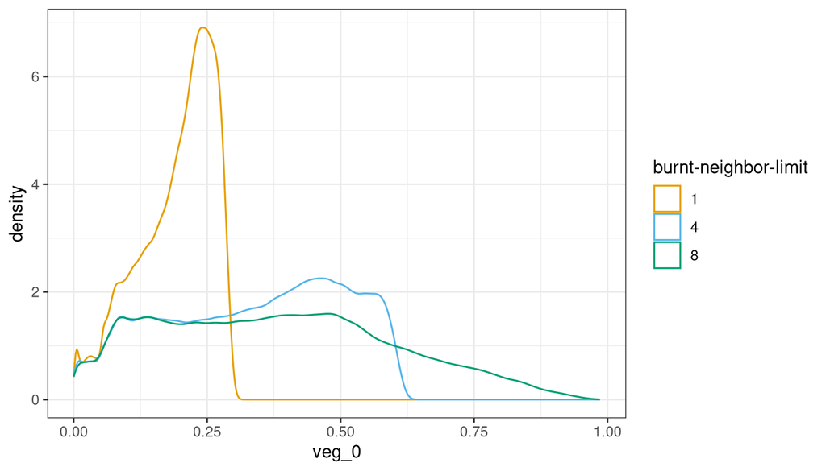

```r
beta.data = data %>% mutate(veg_0 = ifelse(veg_0 == 0, veg_0 + 0.00001, veg_0))

veg_0.burnn1 = beta.data %>% filter(`burnt-neighbor-limit` == 1)
# plotNormalHistogram(veg_0.burnn1$veg_0)
# descdist(veg_0.burnn1$veg_0)
burnn1.fit1 = betareg(veg_0 ~ ticks*(ticks + `natural-ignition` + `cycle-duration` +
                                       `veg-cycle-start` + `veg-distribution` + `burn-cost` + `burn-veg-type-threshold` +
                                       `movement-model`), data = veg_0.burnn1 %>% select_at(c("ticks", "veg_0", parameters[-5])))

veg_0.burnn1 = data %>% filter(`burnt-neighbor-limit` == 1)
burnn1.fit2 = lm(veg_0 ~ ticks*(.), data = veg_0.burnn1 %>% select_at(c("ticks", "veg_0", parameters[-5])))

AIC(burnn1.fit1)
```

```
## [1] -14750649
```

```r
AIC(burnn1.fit2)
```

```
## [1] -18564118
```

```r
veg_0.burnn4 = beta.data %>% filter(`burnt-neighbor-limit` == 4)
# plotNormalHistogram(veg_0.burnn4$veg_0)
# descdist(veg_0.burnn4$veg_0, discrete = F)
burnn4.fit1 = betareg(veg_0 ~ ticks*(ticks + `natural-ignition` + `cycle-duration` +
                                       `veg-cycle-start` + `veg-distribution` + `burn-cost` + `burn-veg-type-threshold` +
                                       `movement-model`), data = veg_0.burnn4 %>% select_at(c("ticks", "veg_0", parameters[-5])))
veg_0.burnn4 = data %>% filter(`burnt-neighbor-limit` == 4)
burnn4.fit2 = lm(veg_0 ~ ticks*(.), data = veg_0.burnn4 %>% select_at(c("ticks", "veg_0", parameters[-5])))

AIC(burnn4.fit1)
```

```
## [1] -11575344
```

```r
AIC(burnn4.fit2)
```

```
## [1] -14428528
```

```r
veg_0.burnn8 = beta.data %>% filter(`burnt-neighbor-limit` == 8)
burnn8.fit1 = betareg(veg_0 ~ ticks*(ticks + `natural-ignition` + `cycle-duration` +
                                       `veg-cycle-start` + `veg-distribution` + `burn-cost` + `burn-veg-type-threshold` +
                                       `movement-model`), data = veg_0.burnn8 %>% select_at(c("ticks", "veg_0", parameters[-5])))
veg_0.burnn8 = data %>% filter(`burnt-neighbor-limit` == 8)
burnn8.fit2 = lm(veg_0 ~ ticks*(.), data = veg_0.burnn8 %>% select_at(c("ticks", "veg_0", parameters[-5])))

AIC(burnn8.fit1)
```

```
## [1] -11946895
```

```r
AIC(burnn8.fit2)
```

```
## [1] -13096774
```

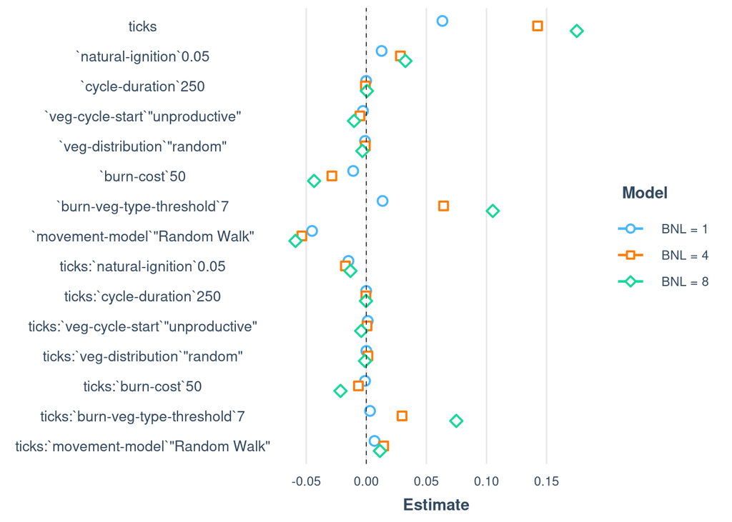

```r
plot_summs(burnn1.fit2, burnn4.fit2, burnn8.fit2, scale = T, digits = 6,
           model.names = c("BNL = 1", "BNL = 4", "BNL = 8"))
```

```r
rm(list = c("beta.data", "veg_0.burnn1", "veg_0.burnn4", "veg_0.burnn8"))
```

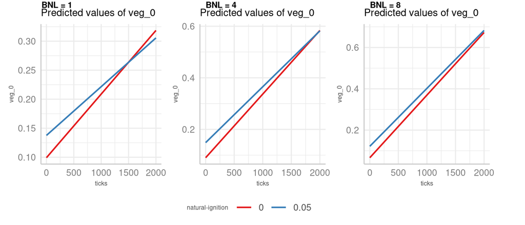

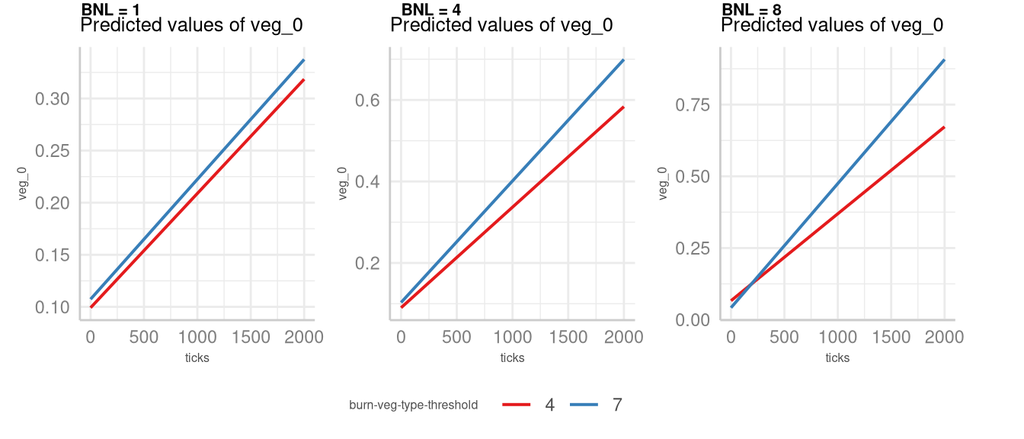

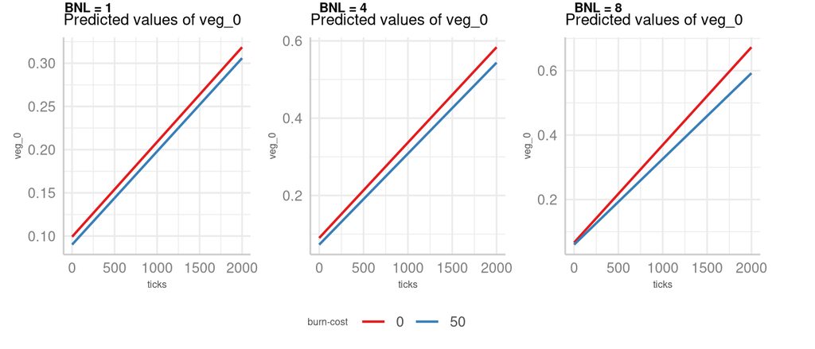

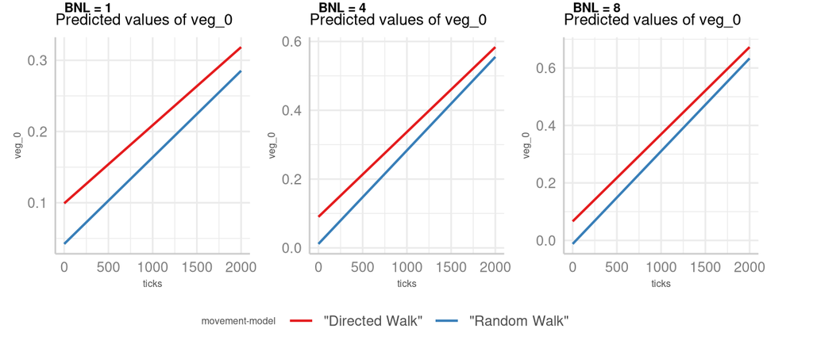

Natural ignition of the landscape obviously results in higher proportions of burnt landscape, especially at the beginning of model run when burning probabilities are low. The ability to burn any patch type (*burn-veg-type-threshold* = 7) and lack of burn cost also results in higher proportions of burnt landscape through time. Finally, directed walks result in more of the landscape be burnt at a given moment throughout model run.

## Spatial clustering of vegetation types

Spatial heterogeneity of vegetation types is assessed via Moran’s I values. We limit our analysis to those significant values of Moran’s I to assess the degree of clustering (positive values) or dispersion (negative values). We assessed the effects of the different parameters using linear regressions.

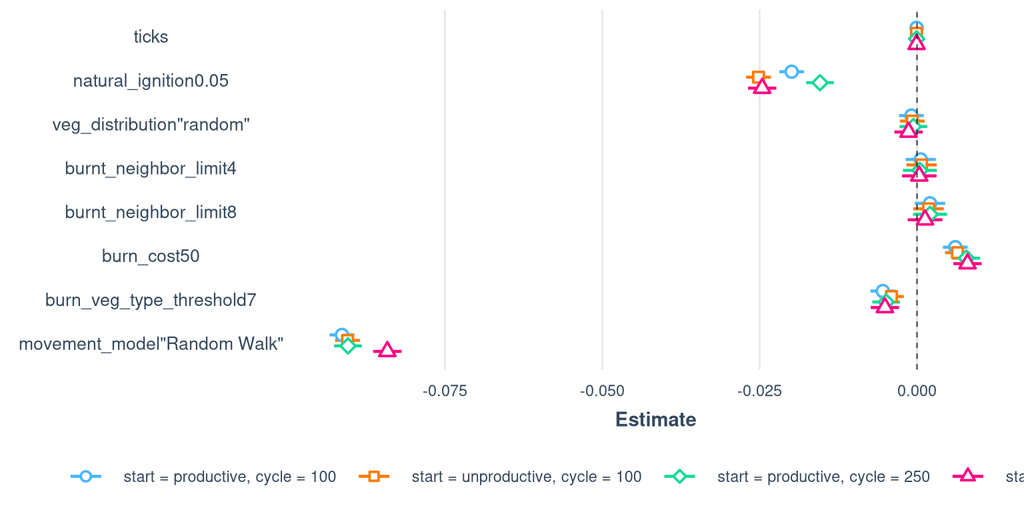

```r
veg.100.prod = readRDS("outputs/veg_moransi_100-prod.rds")
veg.100.unprod = readRDS("outputs/veg_moransi_100-unprod.rds")
veg.250.prod = readRDS("outputs/veg_moransi_250-prod.rds")
veg.250.unprod = readRDS("outputs/veg_moransi_250-unprod.rds")

veg.100.prod = veg.100.prod %>% filter(ticks != 1000) %>% filter(ticks != 2000)
veg.100.unprod = veg.100.unprod %>% filter(ticks != 1000) %>% filter(ticks != 2000)
veg.250.prod = veg.250.prod %>% filter(ticks != 1000) %>% filter(ticks != 2000)
veg.250.unprod = veg.250.unprod %>% filter(ticks != 1000) %>% filter(ticks != 2000)

parameters = c(
  "natural_ignition", # 0.00, 0.05
  "cycle_duration",  # 100, 250
  "veg_cycle_start", # productive, unproductive
  "veg_distribution", # random, clustered
  "burnt_neighbor_limit", # 1, 4, 8
  "burn_cost", # 0, 50
  "burn_veg_type_threshold", # 4, 7
  "movement_model" #Random, Directed
)

reg.params = parameters[c(1,4:8)]
veg.100.prod[,reg.params] = lapply(veg.100.prod[,reg.params], as.factor)
veg.100.unprod[,reg.params] = lapply(veg.100.unprod[,reg.params] , as.factor)
veg.250.prod[,reg.params] = lapply(veg.250.prod[,reg.params], as.factor)
veg.250.unprod[,reg.params] = lapply(veg.250.unprod[,reg.params] , as.factor)

# hist(veg.100.prod$morans.i)
# hist(veg.100.unprod$morans.i)
# hist(veg.250.prod$morans.i)
# hist(veg.250.unprod$morans.i)

veg.100.prod.fit1 = lm(morans.i ~ ticks*(.), data = veg.100.prod %>% filter(signif == T) %>% select_at(c("ticks", "morans.i", reg.params)))

veg.100.unprod.fit1 = lm(morans.i ~ ticks*(.), data = veg.100.unprod %>% filter(signif == T) %>% select_at(c("ticks", "morans.i", reg.params)))

# plot_summs(veg.100.prod.fit1, veg.100.unprod.fit1, digits = 6)

veg.250.prod.fit1 = lm(morans.i ~ ticks*(.), data = veg.250.prod %>% filter(signif == T) %>% select_at(c("ticks", "morans.i", reg.params)))

veg.250.unprod.fit1 = lm(morans.i ~ ticks*(.), data = veg.250.unprod %>% filter(signif == T) %>% select_at(c("ticks", "morans.i", reg.params)))

# plot_summs(veg.250.prod.fit1, veg.250.unprod.fit1, digits = 6)

plot_summs(veg.100.prod.fit1, veg.100.unprod.fit1,veg.250.prod.fit1, veg.250.unprod.fit1, model.names = c(
  "start = productive, cycle = 100",
  "start = unproductive, cycle = 100",
  "start = productive, cycle = 250",
  "start = unproductive, cycle = 250"
), coefs = c("ticks", "natural_ignition0.05", "veg_distribution\"random\"", "burnt_neighbor_limit4", "burnt_neighbor_limit8", "burn_cost50", "burn_veg_type_threshold7", "movement_model\"Random Walk\"")) +
  theme(legend.position = "bottom", legend.title = element_blank())
```

Comparing across individual models for the experiments split by whether the model starts in a productive or unproductive state and split by the model climatic cycle duration, we can see that most of the parameters have similar effects. The parameters with significant differences in regression coefficients between the models are: *movement-model* and *natural-ignition*. We can see that when model run starts in a unproductive state and the climatic cycles are longer, Random Walks do not decrease the value of Moran’s I as much. We can also see that natural ignition has a less negative effect on Moran’s I when the model starts on a productive landscape.

Because spatial autocorrelation of vegetation types is always positive in the model, the negative regression coefficients mean those parameters decrease overall clustering of vegetation types. This means that random walks by foragers (instead of directed walks) result in less clustering of vegetation types, as does natural ignition and the ability to burn any vegetation type. Conversely, when there is a cost to burning, clustering of vegetation types is increased compared to a lack of burn cost.

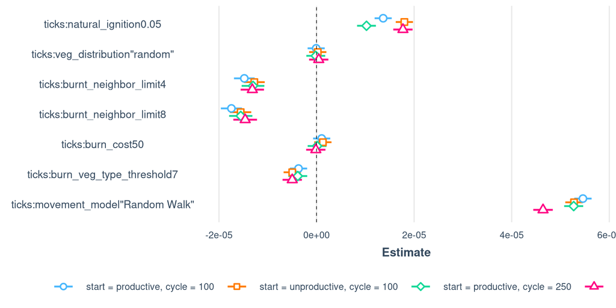

```r
plot_summs(veg.100.prod.fit1, veg.100.unprod.fit1,veg.250.prod.fit1, veg.250.unprod.fit1, model.names = c(
  "start = productive, cycle = 100",
  "start = unproductive, cycle = 100",
  "start = productive, cycle = 250",
  "start = unproductive, cycle = 250"
), omit.coefs = c("(Intercept)","ticks", "natural_ignition0.05", "veg_distribution\"random\"", "burnt_neighbor_limit4", "burnt_neighbor_limit8", "burn_cost50", "burn_veg_type_threshold7", "movement_model\"Random Walk\"")) +
  theme(legend.position = "bottom", legend.title = element_blank())
```

## Vegetation diversity

Vegetation diversity was measured by Shannon’s Diversity Index. This metric considers the proportional abundances of vegetation types to indicate whether one type dominates or abundances are more evenly spread across all types. A SDI value of 0 indicates a lack of diversity with abundance being concentrated in a single species. Higher SDI values indicate more diversity of vegetation types.

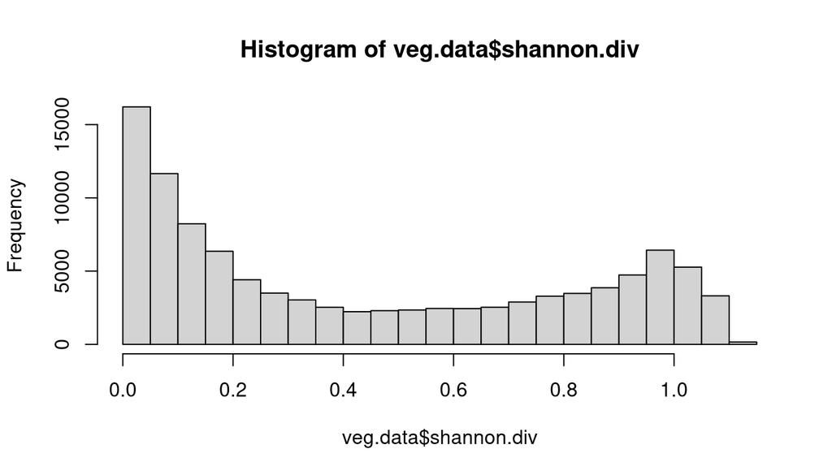

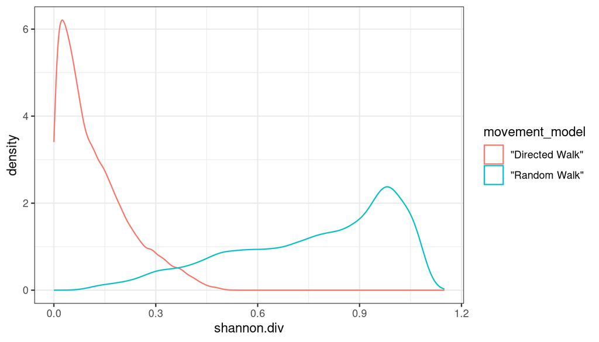

The distribution of this metric is bimodal across model runs, with a high proportion of measurements showing a complete lack of diversity. This bimodality is caused by the different movement models used: directed walks result in less diversity than random walks.

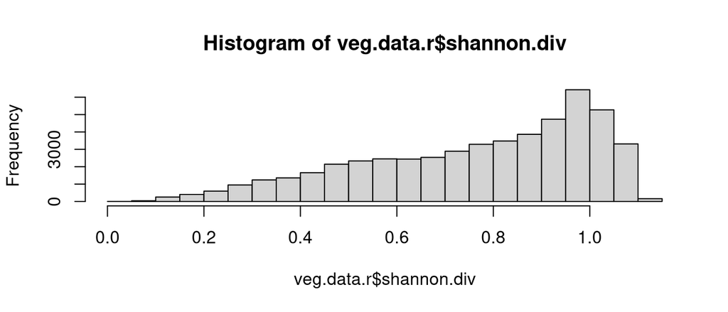

```r
veg.data.r = veg.data %>% filter(movement_model == "\"Random Walk\"")
reg.params = parameters = c(
  "natural_ignition", # 0.00, 0.05
  "cycle_duration",  # 100, 250
  "veg_cycle_start", # productive, unproductive
  "veg_distribution", # random, clustered
  "burnt_neighbor_limit", # 1, 4, 8
  "burn_cost", # 0, 50
  "burn_veg_type_threshold"
)
veg.data.r[,reg.params] = lapply(veg.data.r [,reg.params], as.factor)
hist(veg.data.r$shannon.div)
```

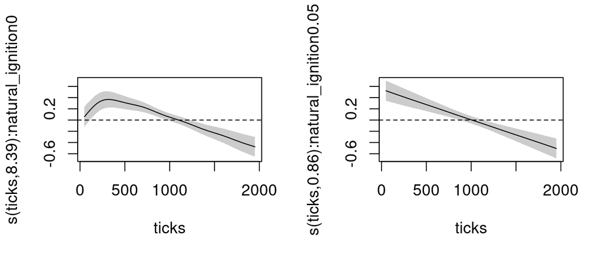

```r
rw.gam1 = gam(shannon.div ~ s(ticks, by = natural_ignition) +
                s(ticks, by = veg_cycle_start) +
                s(ticks, by = veg_distribution) +
                s(ticks, by = burn_cost)  +
                s(ticks, by = burn_veg_type_threshold) +
                s(ticks, by = as.factor(burnt_neighbor_limit)) +
                s(ticks, by = cycle_duration), data = veg.data.r)

par(mfrow=c(1,2), cex=1.1)
plot(rw.gam1, select=1, shade=T)
abline(h=0, lty = 2)
plot(rw.gam1, select=2, shade=T)
abline(h=0, lty = 2)
```

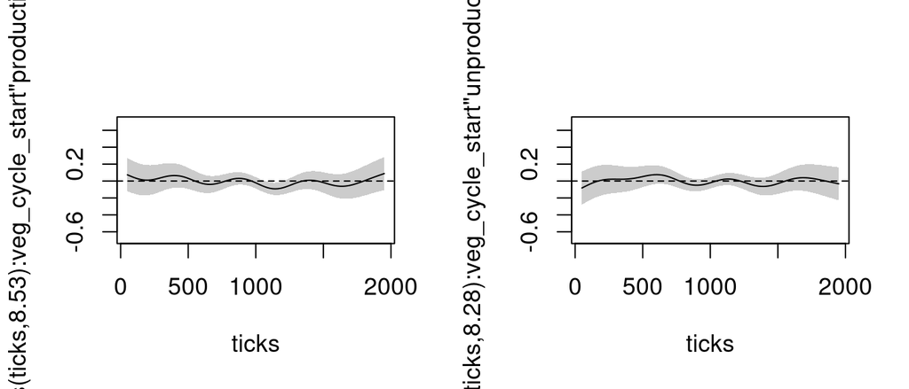

```r
par(mfrow=c(1,2), cex=1.1)
plot(rw.gam1, select=3, shade=T)
abline(h=0, lty = 2)
plot(rw.gam1, select=4, shade=T)
abline(h=0, lty = 2)
```

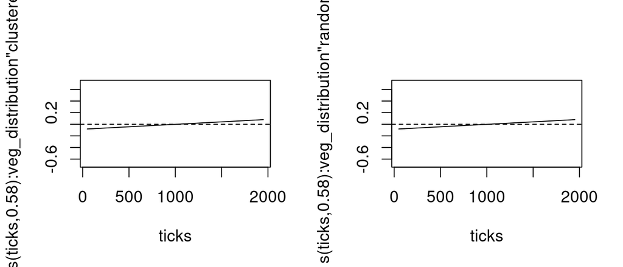

```r
par(mfrow=c(1,2), cex=1.1)
plot(rw.gam1, select=5, shade=T)
abline(h=0, lty = 2)
plot(rw.gam1, select=6, shade=T)
abline(h=0, lty = 2)
```

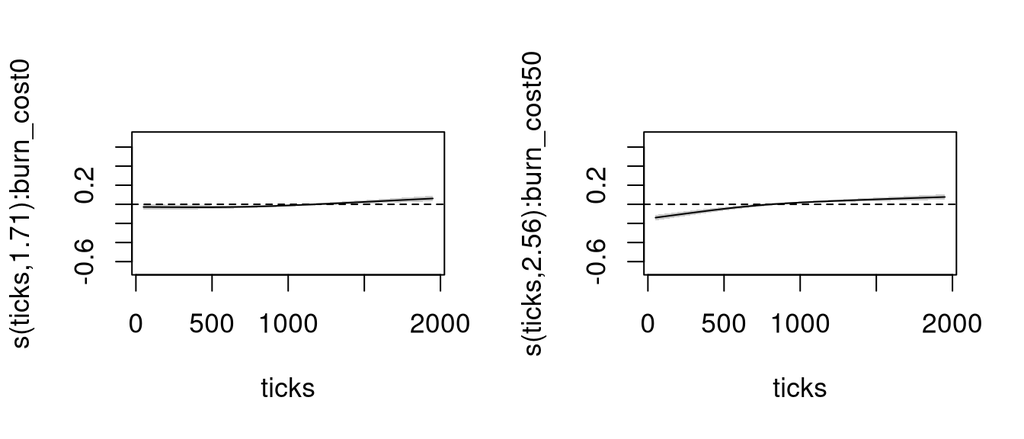

```r
par(mfrow=c(1,2), cex=1.1)
plot(rw.gam1, select=7, shade=T)
abline(h=0, lty = 2)
plot(rw.gam1, select=8, shade=T)
abline(h=0, lty = 2)
```

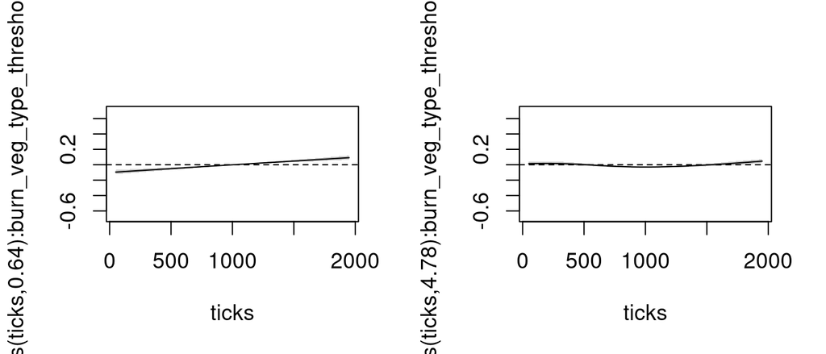

```r
par(mfrow=c(1,2), cex=1.1)
plot(rw.gam1, select=9, shade=T)
abline(h=0, lty = 2)
plot(rw.gam1, select=10, shade=T)
abline(h=0, lty = 2)
```

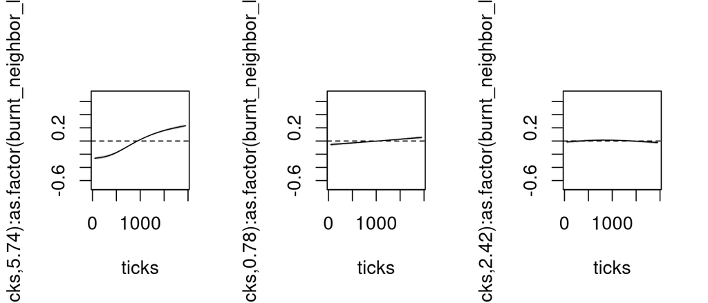

```r
par(mfrow=c(1,3), cex=1.1)
plot(rw.gam1, select=11, shade=T)
abline(h=0, lty = 2)
plot(rw.gam1, select=12, shade=T)
abline(h=0, lty = 2)
plot(rw.gam1, select=13, shade=T)
abline(h=0, lty = 2)
```

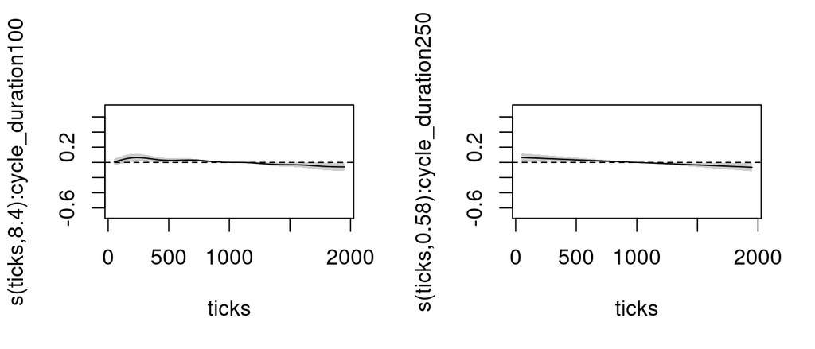

```r
par(mfrow=c(1,2), cex=1.1)
plot(rw.gam1, select=14, shade=T)
abline(h=0, lty = 2)
plot(rw.gam1, select=15, shade=T)
abline(h=0, lty = 2)
```

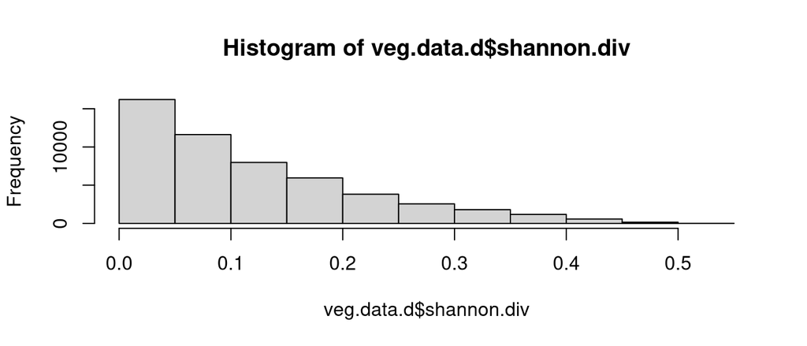

```r
veg.data.d = veg.data %>% filter(movement_model == "\"Directed Walk\"")
reg.params = parameters = c(
  "natural_ignition", # 0.00, 0.05
  "cycle_duration",  # 100, 250
  "veg_cycle_start", # productive, unproductive
  "veg_distribution", # random, clustered
  "burnt_neighbor_limit", # 1, 4, 8
  "burn_cost", # 0, 50
  "burn_veg_type_threshold"
)
veg.data.d[,reg.params] = lapply(veg.data.d[,reg.params], as.factor)
hist(veg.data.d$shannon.div)
```